# Is Denny’s Close to Laquinta?

Weiyun Huang, Kyle Monette, Jordan Patoine, Victoria York

October 28, 2021

```r
library(tidyverse)
library(devtools)
# to install dsbox, devtools::install_github("rstudio-education/dsbox")
library(dsbox)
library(kableExtra)
library(here)
```

The purpose of this project is to check the validity of the joke made by comedian [Mitch Hedberg](https://en.wikipedia.org/wiki/Mitch_Hedberg) when he said “La Quinta is Spanish for ‘next to Denny’s’”. We approached this problem by first finding the average distance between a La Quinta and its nearest Denny’s by state (data courtesy of datascienceinabox.org).

To test the validity of this statement, we decided to see if Denny’s was closer to La Quinta’s on average then a given fast food restaurant. To do so we used sample data of a subset of 10000 fast food restaurants locations around the US along with data showing the locations of Denny’s and La Quinta’s.

```r
states <- read_csv(here("data", "states.csv"), show_col_types = FALSE)
rest <- read_csv(here("data", "FastFoodRestaurants.csv"), col_types = cols(address = col_skip(), keys = col_skip(), websites = col_skip()), show_col_types = FALSE) %>%
  rename(state = province)

# create local copy of data sets from dsbox
dennys <- dsbox::dennys
laquinta <- dsbox::laquinta
```

## Explanation of Functions

We use the following functions, which are called nested in this order:

The function `rest_state` takes in a state and restaurant and outputs a data frame. The data frame is grouped by the name of restaurants (Dennys and the input one), and contains the minimum distance to the nearest Laquinta.

The function `state_pvalue` takes in a data frame (namely the output of `rest_state`) and a restaurant as inputs. The point of this function is to compute the t-test values (mean, p-value, standard deviation, etc.) for the test in which mean distance of Dennys to Laquinta is compared to the given restaurant to Laquinta. The output is this list of results from the t-test.

The function `analyze_rest` takes in a restaurant, number of iterations, and alpha, and outputs a data frame with states and their p-values if the p-values are statistically significant. It was necessary to include `state_pvalue` as a separate function to have the `replicate` function inside `analyze_rest` work; it also makes the program more modular.

The function `create_plot` is a global function that takes a restaurant, the number of iterations to be done per state, and the alpha level for the test as input, and outputs the distribution plots as well as summary statistic values. This allows us to only enter one variable into one function.

## Statistical Test

Here, we consider the two-sample t-test, with null hypothesis that the mean distance from Dennys to Laquinta equals the mean distance from a given restaurant to Laquinta. Therefore, the alternative hypothesis is that the average distance from Dennys to Laquinta is less than that of another restaurant to Laquinta.

## Small-Scale Example

Let’s consider McDonald’s in California. We specify `num_itr`, the number of random samples in each state that should be taken to compute the test, and `alpha`, the significance level for the t-test.

Here, the code is modified from the `analyze_rest` and `create_plot` functions.

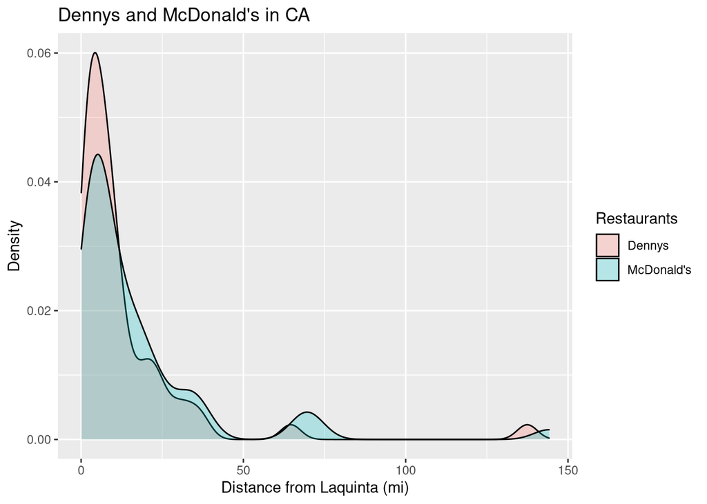

```r
num_itr = 100
alpha = 0.1

# determine how many lq's, dn's, and McDonald's are in CA
lq_count <- laquinta %>%
  group_by(state) %>%
  select(state) %>%
  filter(state == "CA") %>%
  mutate(num_state = n()) %>%
  distinct()
dn_count <- dennys %>%
  group_by(state) %>%
  select(state) %>%
  filter(state == "CA") %>%
  mutate(num_state = n()) %>%
  distinct()
this_rest_count <- rest %>%
  select(state, name) %>%
  group_by(state) %>%
  filter(state == "CA") %>%
  filter(name == "McDonald's") %>%
  mutate(num_state = n()) %>%
  distinct()

# join the above 3 data frames together for comparison/filtering purposes
rest_count <- full_join(lq_count, dn_count, by = "state") %>%
  rename(lq = num_state.x, dn = num_state.y)

rest_count <- full_join(rest_count, this_rest_count, by = "state") %>%
  rename("McDonald's" = num_state) %>%
  # the t-test requires > 1 of each restaurant in each state
  # here we choose the following cutoffs to ensure reasonable conclusions
  filter(lq > 5 && dn > 5 && "McDonald's" > 5)

# in each state, num_itr says how many random samples we should take before
# averaging the p-values. Note the computational cost by increasing num_itr.

rest_states_pvalues <- rest_count %>%
    select(state) %>%
    rowwise() %>%
    mutate(avg_pvalue = mean(replicate(num_itr,
          {state_pvalue(rest_state(state, "McDonald's"), "McDonald's")$p.value }
        )
      )
    ) %>%
    # only include those that have a statistically significant p-value
    filter(avg_pvalue < alpha)

ca_df <- rest_state("CA", "McDonald's")
print(ggplot(ca_df, aes(x = closest, fill = place))
  + geom_density(alpha = 0.25)
  + ggtitle(paste("Dennys and McDonald's in CA"))
   + labs(x = "Distance from Laquinta (mi)", y = "Density", fill = "Restaurants"))
```

```r
print("Dennys")
```

[1] “Dennys”

```r
print(summary(ca_df %>% filter(place == "Dennys")))
```

```
closest           place
```

Min. : 0.058 Length:56  
1st Qu.: 3.021 Class :character  
Median : 7.120 Mode :character  
Mean : 12.951  
3rd Qu.: 13.364  
Max. :137.437

```r
print("McDonald's")
```

[1] “McDonald’s”

```r
print(summary(ca_df %>% filter(place == "McDonald's")))
```

```
closest           place
```

Min. : 0.298 Length:56  
1st Qu.: 3.705 Class :character  
Median : 8.159 Mode :character  
Mean : 16.942  
3rd Qu.: 19.341  
Max. :144.169

## Testing Across Multiple States

### McDonald’s

Now we can begin to determine the validity of the joke on a larger scale, namely, while keeping a restaurant fixed and considering all states. Here, we fix McDonald’s as a restaurant, and later we will consider others.

We’ll decrease `num_itr` at this point for faster computations, and keep `alpha` the same at `0.1`.

```r
num_itr = 20
```

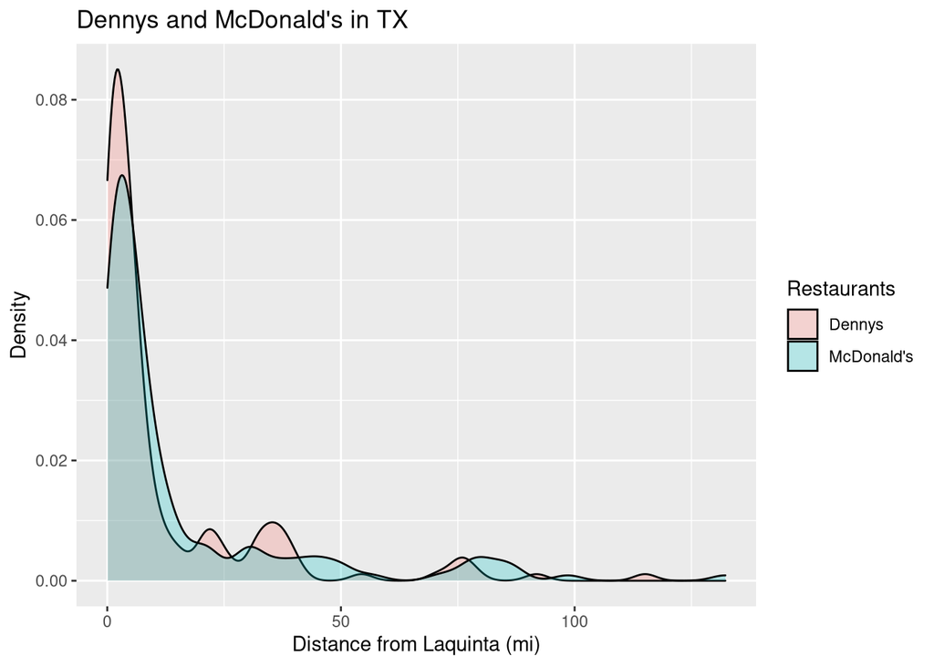

```r
this_rest = "McDonald's"
create_plot(this_rest, num_itr, alpha)
```

[1] “” [1] “TX” [1] “Dennys” closest place  
Min. : 0.026 Length:153  
1st Qu.: 1.457 Class :character  
Median : 3.816 Mode :character  
Mean : 12.003  
3rd Qu.: 11.122  
Max. :115.082  
[1] “” [1] “McDonald’s” closest place  
Min. : 0.092 Length:153  
1st Qu.: 2.196 Class :character  
Median : 5.349 Mode :character  
Mean : 15.418  
3rd Qu.: 14.063  
Max. :132.254

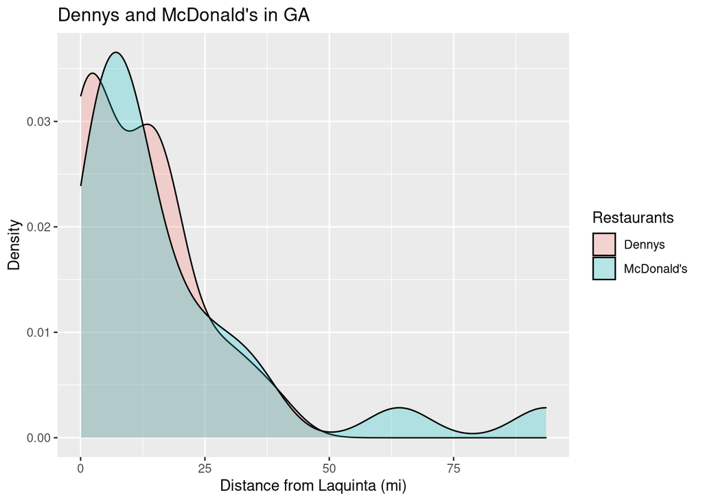

[1] “” [1] “GA” [1] “Dennys” closest place  
Min. : 0.044 Length:22  
1st Qu.: 1.351 Class :character  
Median :12.617 Mode :character  
Mean :11.421  
3rd Qu.:16.073  
Max. :38.656  
[1] “” [1] “McDonald’s” closest place  
Min. : 1.333 Length:22  
1st Qu.: 5.402 Class :character  
Median : 9.139 Mode :character  
Mean :18.323  
3rd Qu.:23.011  
Max. :93.571  
### Wendy’s

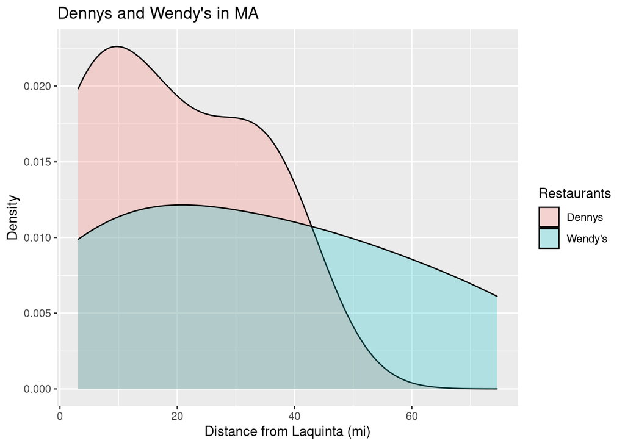

```r
create_plot("Wendy's", num_itr, alpha)
```

[1] “” [1] “MA” [1] “Dennys” closest place  
Min. : 3.187 Length:6  
1st Qu.: 6.519 Class :character  
Median :16.730 Mode :character  
Mean :18.625  
3rd Qu.:30.610  
Max. :36.753  
[1] “” [1] “Wendy’s” closest place  
Min. : 3.112 Length:6  
1st Qu.:12.918 Class :character  
Median :31.433 Mode :character  
Mean :33.743  
3rd Qu.:49.259  
Max. :74.531

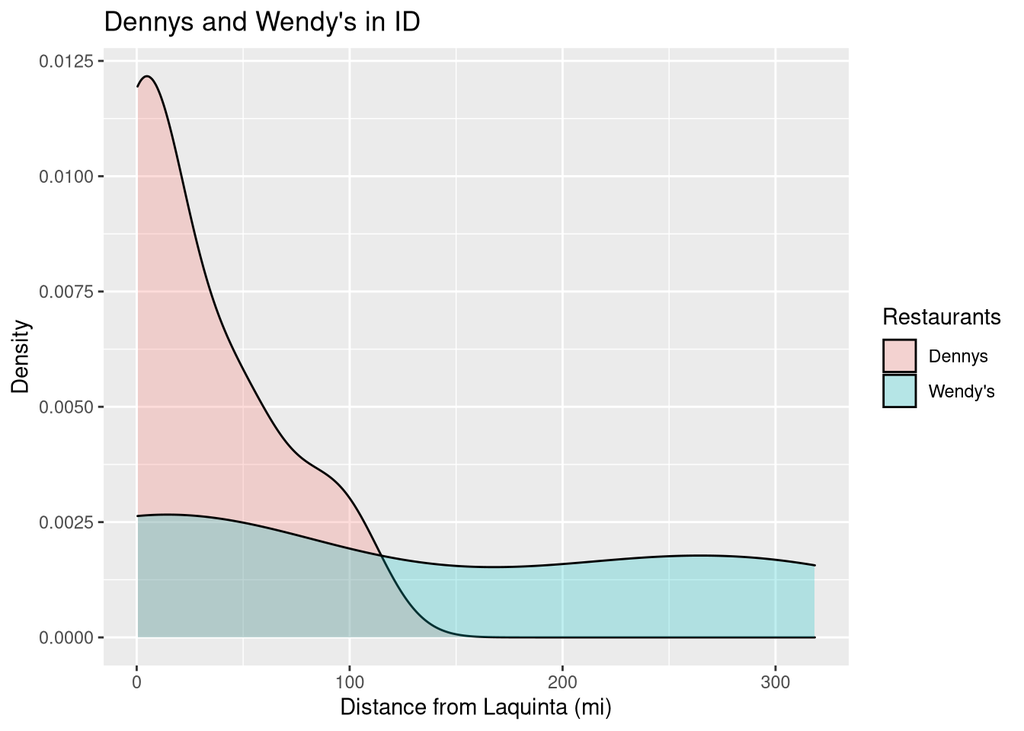

[1] “” [1] “ID” [1] “Dennys” closest place  
Min. : 0.395 Length:7  
1st Qu.: 1.673 Class :character  
Median : 3.755 Mode :character  
Mean :27.738  
3rd Qu.:45.873  
Max. :94.919  
[1] “” [1] “Wendy’s” closest place  
Min. : 1.040 Length:7  
1st Qu.: 9.005 Class :character  
Median : 20.355 Mode :character  
Mean :121.263  
3rd Qu.:245.486  
Max. :318.461

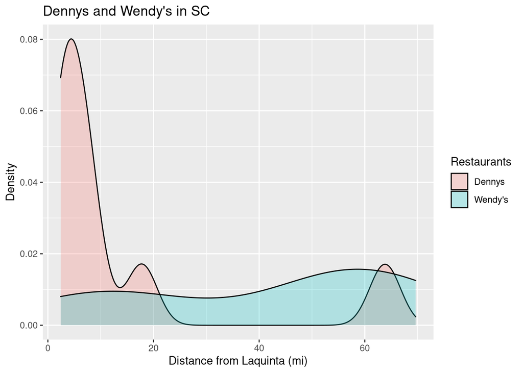

[1] “” [1] “SC” [1] “Dennys” closest place  
Min. : 2.406 Length:8  
1st Qu.: 3.658 Class :character  
Median : 5.931 Mode :character  
Mean :13.767  
3rd Qu.:10.247  
Max. :63.828  
[1] “” [1] “Wendy’s” closest place  
Min. : 4.775 Length:8  
1st Qu.:15.845 Class :character  
Median :55.874 Mode :character  
Mean :41.356  
3rd Qu.:57.797  
Max. :69.641

### Burger King

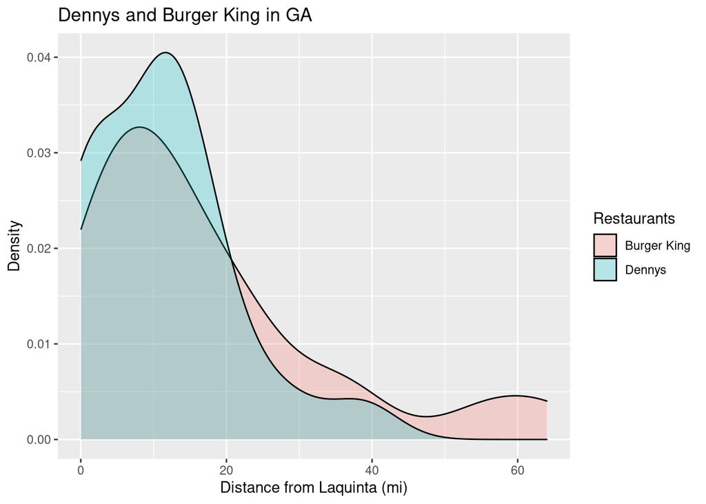

```r
create_plot("Burger King", num_itr, alpha)
```

[1] “” [1] “GA” [1] “Dennys” closest place  
Min. : 0.044 Length:22  
1st Qu.: 1.554 Class :character  
Median :10.954 Mode :character  
Mean :11.112  
3rd Qu.:15.023  
Max. :38.656  
[1] “” [1] “Burger King” closest place  
Min. : 0.59 Length:22  
1st Qu.: 4.83 Class :character  
Median :11.49 Mode :character  
Mean :17.14  
3rd Qu.:22.27  
Max. :63.99

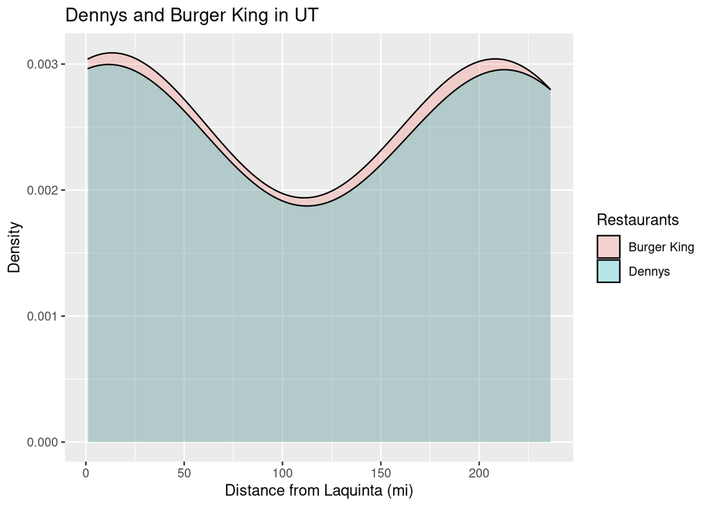

[1] “” [1] “UT” [1] “Dennys” closest place  
Min. : 1.153 Length:8  
1st Qu.: 2.090 Class :character  
Median :110.415 Mode :character  
Mean :112.124  
3rd Qu.:216.635  
Max. :236.107  
[1] “” [1] “Burger King” closest place  
Min. : 1.717 Length:8  
1st Qu.: 5.722 Class :character  
Median :108.648 Mode :character  
Mean :110.670  
3rd Qu.:211.986  
Max. :231.529

### Domino’s Pizza

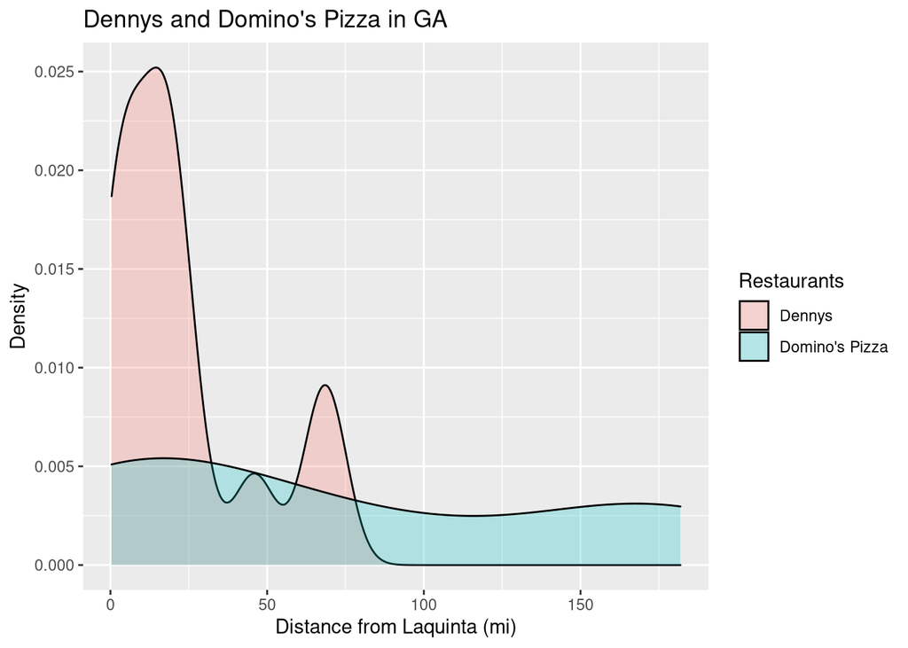

```r
create_plot("Domino's Pizza", num_itr, alpha)
```

[1] “” [1] “GA” [1] “Dennys” closest place  
Min. : 0.366 Length:13  
1st Qu.: 7.943 Class :character  
Median :16.458 Mode :character  
Mean :23.081  
3rd Qu.:24.642  
Max. :69.086  
[1] “” [1] “Domino’s Pizza” closest place  
Min. : 2.077 Length:13  
1st Qu.: 6.595 Class :character  
Median : 50.853 Mode :character  
Mean : 71.827  
3rd Qu.:159.022  
Max. :181.874

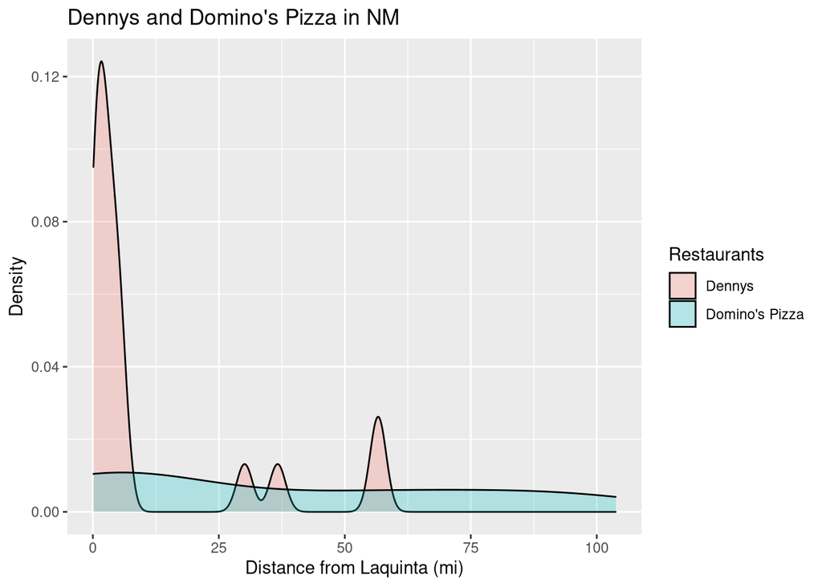

[1] “” [1] “NM” [1] “Dennys” closest place  
Min. : 0.112 Length:19  
1st Qu.: 1.113 Class :character  
Median : 2.743 Mode :character  
Mean :11.430  
3rd Qu.: 5.371  
Max. :56.745  
[1] “” [1] “Domino’s Pizza” closest place  
Min. : 0.521 Length:19  
1st Qu.: 2.233 Class :character  
Median : 22.836 Mode :character  
Mean : 37.067  
3rd Qu.: 64.276  
Max. :103.739

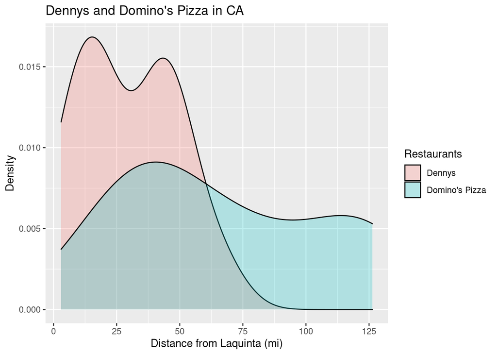

[1] “” [1] “CA” [1] “Dennys” closest place  
Min. : 2.986 Length:16  
1st Qu.:16.401 Class :character  
Median :27.102 Mode :character  
Mean :29.864  
3rd Qu.:45.333  
Max. :66.361  
[1] “” [1] “Domino’s Pizza” closest place  
Min. : 9.262 Length:16  
1st Qu.: 37.062 Class :character  
Median : 56.528 Mode :character  
Mean : 67.165  
3rd Qu.:101.892  
Max. :126.339

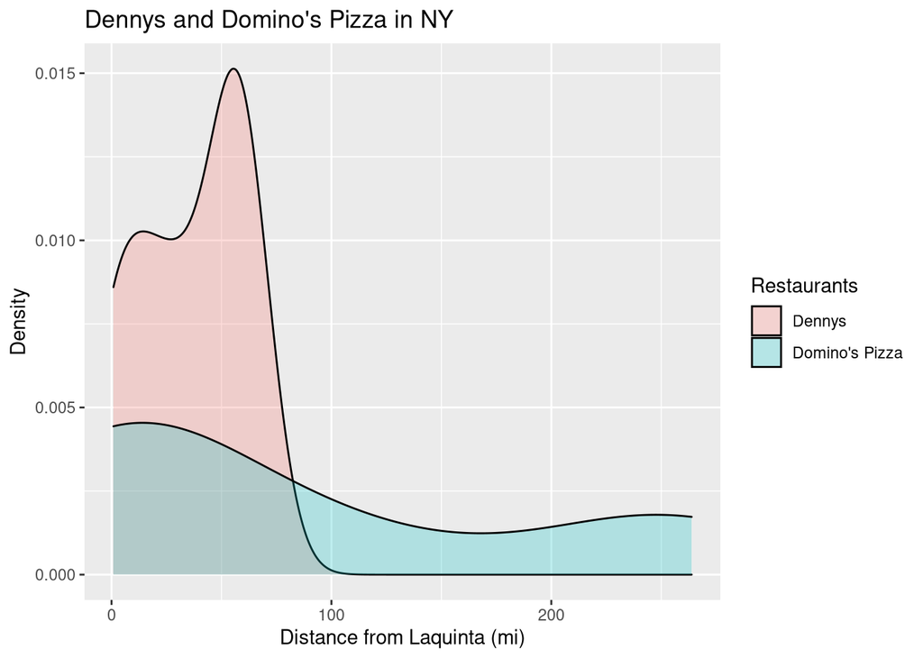

[1] “” [1] “NY” [1] “Dennys” closest place  
Min. : 0.864 Length:12  
1st Qu.:17.074 Class :character  
Median :41.704 Mode :character  
Mean :36.340  
3rd Qu.:58.154  
Max. :64.955  
[1] “” [1] “Domino’s Pizza” closest place  
Min. : 3.184 Length:12  
1st Qu.: 4.802 Class :character  
Median : 11.863 Mode :character  
Mean : 83.195  
3rd Qu.:139.706  
Max. :263.821

## Appendix: Code

### Haversine Function

```r
haversine = function(long1, lat1, long2, lat2, round = 3) {
  # convert to radians
  long1 = long1 * pi / 180
  lat1  = lat1  * pi / 180
  long2 = long2 * pi / 180
  lat2  = lat2  * pi / 180

  # Earth mean radius in km
  R = 6371
  a = sin((lat2 - lat1)/2)^2 + cos(lat1) * cos(lat2) * sin((long2 - long1)/2)^2
  d = R * 2 * asin(sqrt(a))

  # outputs distance in miles (because we're not Brits)
  return(round(d/1.609, round))
}
```

### rest_state Function

```r
rest_state = function (this_state, this_rest)
{
  # filter dennys and laquinta by the state
  dn_state <- dennys %>%
    filter(state == this_state)
  lq_state = laquinta %>%
    filter(state == this_state)

  # create data frame of all this_rest in this_state
  this_rest_state <- rest %>%
    filter(state == this_state & name == this_rest)

  n_this_rest_state = nrow(this_rest_state)
  n_dn_state = nrow(dn_state)
  n_lq_state = nrow(lq_state)
  # We need an equal number of occurrences of this_rest and dennys per state
  # to ensure the (later) statistical test is less biased.
  # Therefore, choose the minimum of these values
  n_min = min(n_this_rest_state, n_dn_state, n_lq_state)

  # create subsets that have n_min rows, randomly chosen
  dn_sub <- dn_state[sample(nrow(dn_state), n_min),]
  rest_sub <- this_rest_state[sample(nrow(this_rest_state), n_min),]
  lq_sub <- lq_state[sample(nrow(lq_state), n_min),]

  # make filtered data frames by state that have the randomly selected locations
  # then compute the distances from each restaurant to the other
  dn_lq_state <- full_join(lq_sub, dn_sub, by = "state") %>%
    mutate(
      distance = haversine(longitude.x, latitude.x, longitude.y, latitude.y)
    )
  rest_lq_state <- full_join(lq_sub, rest_sub, by = "state") %>%
    rename(address.x = address) %>%
    mutate(
      distance = haversine(longitude.x, latitude.x, longitude.y, latitude.y)
    )

  # compute the minimum distances from the above data frames
  dn_lq_state_mindist <- dn_lq_state %>%
    group_by(address.x) %>%
    summarise(closest = min(distance))
  rest_lq_state_mindist <- rest_lq_state %>%
    group_by(address.x) %>%
    summarise(closest = min(distance))

  # it is best to "stack" the data at this point: create 1 column for distance,
  # and 1 column for the place (the restaurant that's being compared to laquinta)
  df1 <- rest_lq_state_mindist %>%
    mutate(place = this_rest) %>%
    select(closest, place)
  df2 <- dn_lq_state_mindist %>%
    mutate(place = "Dennys") %>%
    select(closest, place)

  # create the stacked data, and return the 2 col data frame
  # this is also done to be able to return the entire data frame
  df <- bind_rows(df1, df2)
  return(df)
}
```

### state_pvalue Function

```r
state_pvalue = function(df, this_rest)
{
  # create 2 data frames (one for Dennys, one for the other restaurant)
  # this is needed to run the t.test
  df_dn <- df %>% filter(place == "Dennys")
  df_rest <- df %>% filter(place == this_rest)
  # var.equal is false because we cannot assume the distributions have the same variances
  test = t.test(df_dn$closest, df_rest$closest, alternative = "less" , var.equal = FALSE)

  #return the test "matrix" of parameter values (mean, p-value, sd, etc)
  return(test)
}
```

```r
analyze_rest = function(this_rest, num_itr, alpha)
{
  # determine how many lq's, dn's, and this_rest's are in each state
  lq_count <- laquinta %>%
    group_by(state) %>%
    select(state) %>%
    filter(state %in% states$abbreviation) %>%
    mutate(num_state = n()) %>%
    distinct()

  dn_count <- dennys %>%
    group_by(state) %>%
    select(state) %>%
    filter(state %in% states$abbreviation) %>%
    mutate(num_state = n()) %>%
    distinct()

  this_rest_count <- rest %>%
    select(state, name) %>%
    group_by(state) %>%
    filter(state %in% states$abbreviation) %>%
    filter(name == this_rest) %>%
    mutate(num_state = n()) %>%
    distinct()

  # join the above 3 data frames together for comparison/filtering purposes
  rest_count <- full_join(lq_count, dn_count, by = "state") %>%
    rename(lq = num_state.x, dn = num_state.y)

  rest_count <- full_join(rest_count, this_rest_count, by = "state") %>%
    rename(this_rest = num_state) %>%
    # the t-test requires > 1 of each restaurant in each state
    # here we choose the following cutoffs to ensure reasonable conclusions
    filter(lq > 5 && dn > 5 && this_rest > 5)

  # set the value of alpha for the test
  #alpha = 0.1

  # in each state, num_itr says how many random samples we should take before
  # averaging the p-values. Note the computational cost by increasing num_itr.
  #num_itr = 10
  rest_states_pvalues <- rest_count %>%
    select(state) %>%
    rowwise() %>%
    mutate(
      avg_pvalue = mean(replicate(num_itr, {state_pvalue(rest_state(state, this_rest), this_rest)$p.value }))
    ) %>%
    # only include those that have a statistically significant p-value
    filter(avg_pvalue < alpha)

  #return a data frame of states that have significant p-values for the given this_rest
  return(rest_states_pvalues)
}
```

### create_plot Function

```r
create_plot = function(this_rest, num_itr, alpha)
{
  rest_states_pvalues <- analyze_rest(this_rest, num_itr, alpha)
  # if no states for this_rest have significant p-values, we can't create the table below.
  if (nrow(rest_states_pvalues) == 0)
  {
    cat("No states had a significant p-value","\n")
  } else {
    rest_states_pvalues %>%
      kbl(col.names = c("State", "P-value"), caption = "Significant p-values", digits = 4) %>%
      kable_minimal(full_width = F, position = "left")

    # create data frame of states that had significant p-values
    df <- rest_states_pvalues %>% select(state)
    # iterate through and print plots and summaries
    for (i in 1:nrow(df))
    {
      # run functions above on each state in the list of df
      state_df <- rest_state(df$state[i], this_rest)

      # create the plots using ggplot
      print(ggplot(state_df, aes(x = closest, fill = place))
          + geom_density(alpha = 0.25)
          + ggtitle(paste("Dennys and", this_rest, "in", df$state[i]))
          + labs(x = "Distance from Laquinta (mi)", y = "Density", fill = "Restaurants"))

      # output the state so we can tell what the summary is for
      print("\n")
      print(df$state[i])
      print("Dennys")
      print(summary(state_df %>% filter(place == "Dennys")))
      print("\n")
      print(this_rest)
      print(summary(state_df %>% filter(place == this_rest)))
    }
  }
}
```